# GGPLOT2

# Title, subtitle, caption and tag in ggplot2

When using ggplot2 you can set a title, a subtitle, a caption and a tag. There are two ways to add titles: using ggtitle or labs function. The former is only for titles and subtitles and the latter also allows adding tags and captions.

## Title

### Option 1. Using ggtitle

Adding a title in ggplot2 with ggtitle

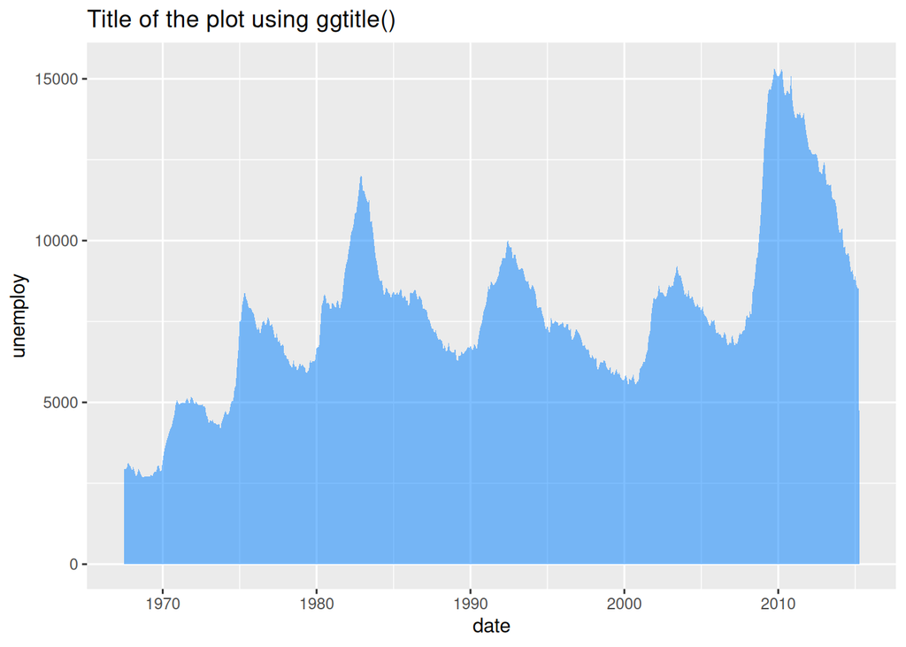

```r
# install.packages(ggplot2)
library(ggplot2)

ggplot(economics, aes(date, unemploy)) +
  geom_area(fill = rgb(0, 0.5, 1, alpha = 0.5)) +
  ggtitle("Title of the plot using ggtitle()")
```

### Option 2. Using labs

You can also use the labs function to add the title.

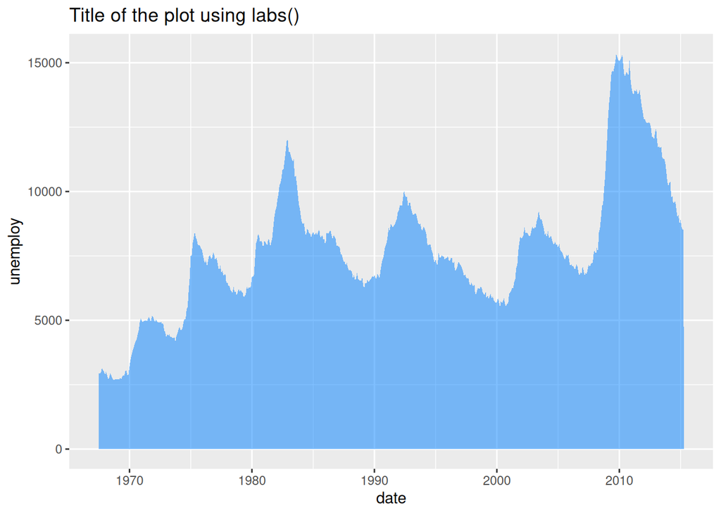

```r
# install.packages(ggplot2)
library(ggplot2)

ggplot(economics, aes(date, unemploy)) +
  geom_area(fill = rgb(0, 0.5, 1, alpha = 0.5)) +
  labs(title = "Title of the plot using labs()")
```

### Title position

The title position can be set respect to the whole plot instead of the panel with the plot.title.position component of the theme function. Default value is “panel”. This configuration also applies to the subtitle.

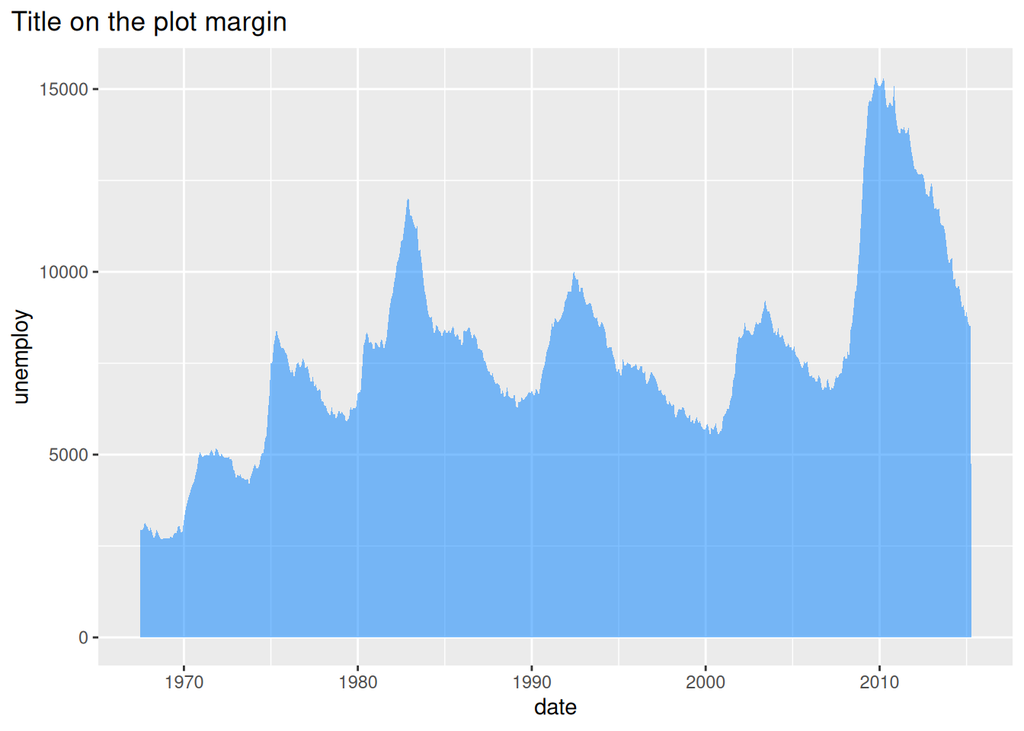

```r
# install.packages(ggplot2)
library(ggplot2)

ggplot(economics, aes(date, unemploy)) +
  geom_area(fill = rgb(0, 0.5, 1, alpha = 0.5)) +
  labs(title = "Title on the plot margin") +
  theme(plot.title.position = "plot")
```

## Subtitle

You can add a subtitle the same way you added the title, but with the subtitle argument.

### Option 1. Using ggtitle

Add a subtitle in ggplot2

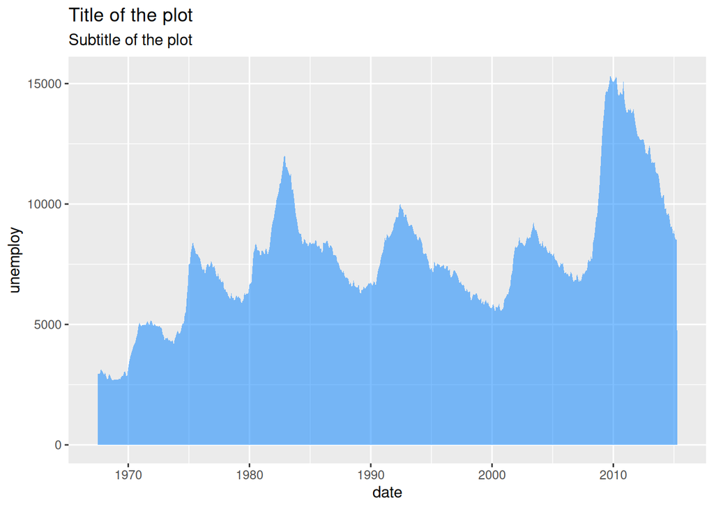

```r
# install.packages(ggplot2)
library(ggplot2)

ggplot(economics, aes(date, unemploy)) +
  geom_area(fill = rgb(0, 0.5, 1, alpha = 0.5)) +
  ggtitle("Title of the plot",
          subtitle = "Subtitle of the plot")
```

### Option 2. Using labs

Subtitle in ggplot2 using labs

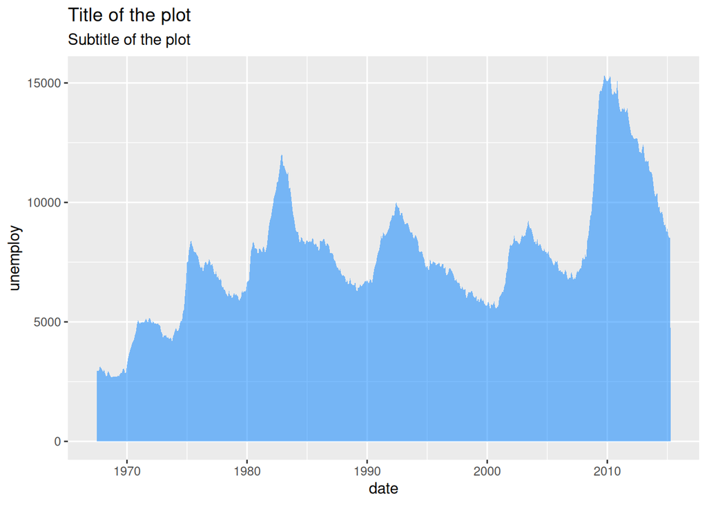

```r
# install.packages(ggplot2)
library(ggplot2)

ggplot(economics, aes(date, unemploy)) +
  geom_area(fill = rgb(0, 0.5, 1, alpha = 0.5)) +
  labs(title = "Title of the plot",
       subtitle = "Subtitle of the plot")
```

## Caption

A caption can be used to describe the figure. You can add it with the caption argument of the labs function.

Adding a caption in ggplot2

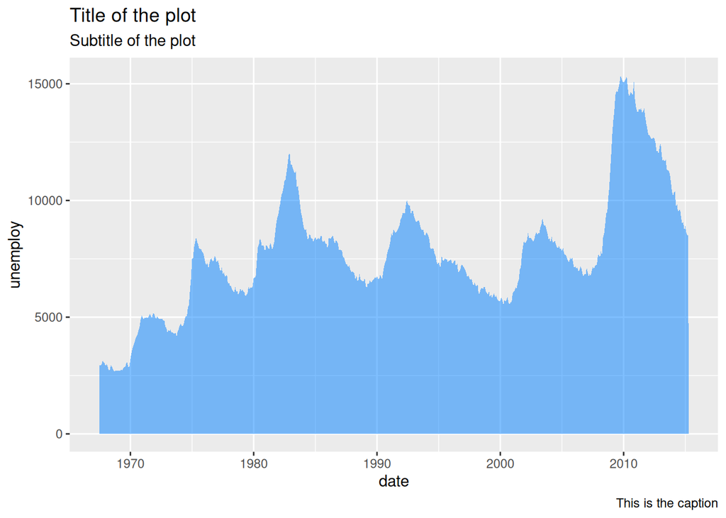

```r
# install.packages(ggplot2)
library(ggplot2)

ggplot(economics, aes(date, unemploy)) +
  geom_area(fill = rgb(0, 0.5, 1, alpha = 0.5)) +
  labs(title = "Title of the plot",
       subtitle = "Subtitle of the plot",
       caption = "This is the caption")
```

The plot.caption.position of the theme function allows aliging the caption to the panel (“panel”, default) or the whole plot (“plot”).

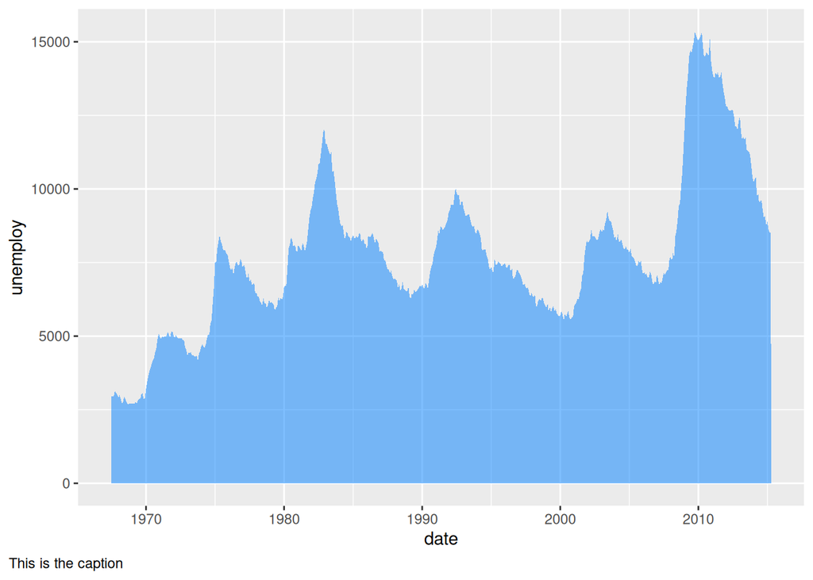

```r
# install.packages(ggplot2)
library(ggplot2)

ggplot(economics, aes(date, unemploy)) +
  geom_area(fill = rgb(0, 0.5, 1, alpha = 0.5)) +
  labs(caption = "This is the caption") +
  theme(plot.caption.position = "plot",
        plot.caption = element_text(hjust = 0))
```

Changing the caption position in ggplot2

Note that the default for the caption is right alignment, so you can set hjust = 0 to move the caption to the left of the whole plot.

## Tag

Adding a tag to the plot in ggplot2

Tags are useful to indicate the figure numbering. You can add it with the tag argument of the labs function.

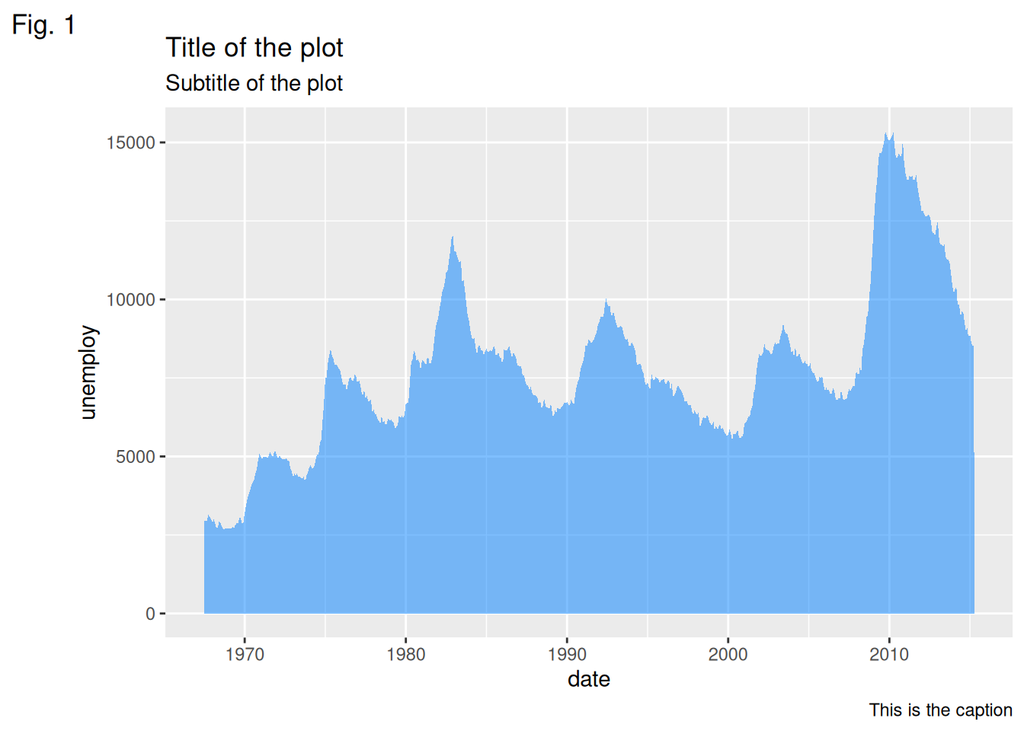

```r
# install.packages(ggplot2)
library(ggplot2)

ggplot(economics, aes(date, unemploy)) +
  geom_area(fill = rgb(0, 0.5, 1, alpha = 0.5)) +
  labs(title = "Title of the plot",
       subtitle = "Subtitle of the plot",
       caption = "This is the caption",
       tag = "Fig. 1")
```

### Tag position

Changing the tag position in ggplot2

The position of the tag can be set with the plot.tag.position component of the theme function. Possible values are “topleft” (default), “top”, “topright”, “left”, “right”, “bottomleft”, “bottom” or “bottomright”.

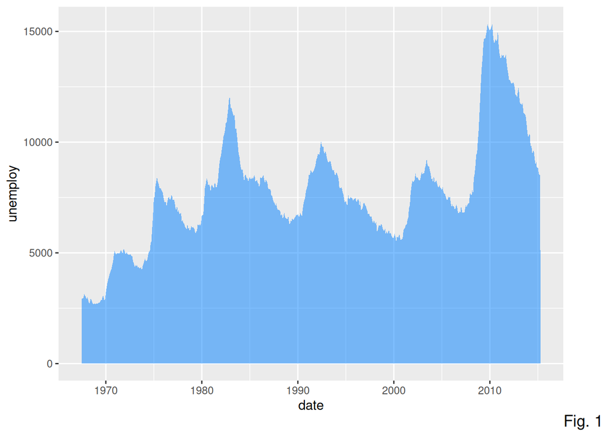

```r
# install.packages(ggplot2)
library(ggplot2)

ggplot(economics, aes(date, unemploy)) +
  geom_area(fill = rgb(0, 0.5, 1, alpha = 0.5)) +
  labs(tag = "Fig. 1") +
  theme(plot.tag.position = "bottomright")
```

## Further styles and adjustments

The titles, subtitles, captions and tags can be customized with the plot.title, plot.subtitle, plot.caption and plot.tag components of the theme function, making use of element_text. You can modify the color, the font family, the text size, the text face, the angle or the vertical and horizontal adjustment for each text as in the example below.

Styling the titles in ggplot2, such as modifying the color, size, face, family, lineheight and margins

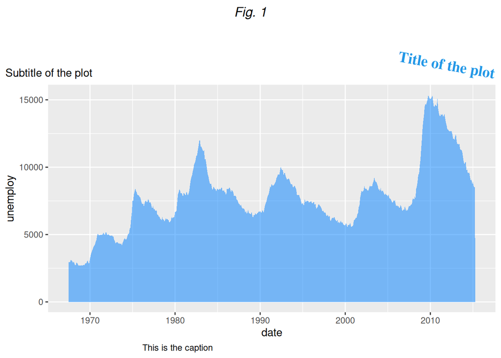

```r
# install.packages(ggplot2)
library(ggplot2)

ggplot(economics, aes(date, unemploy)) +
  geom_area(fill = rgb(0, 0.5, 1, alpha = 0.5)) +
  labs(title = "Title of the plot",
       subtitle = "Subtitle of the plot",
       caption = "This is the caption",
       tag = "Fig. 1") +
  theme(plot.title = element_text(family = "serif",              # Font family
                                  face = "bold",                 # Font face
                                  color = 4,                     # Font color
                                  size = 15,                     # Font size
                                  hjust = 1,                     # Horizontal adjustment
                                  vjust = 1,                     # Vertical adjustment
                                  angle = -10,                   # Font angle
                                  lineheight = 1,                # Line spacing
                                  margin = margin(20, 0, 0, 0)), # Margins (t, r, b, l)
        plot.subtitle = element_text(hjust = 0),                 # Subtitle customization
        plot.caption = element_text(hjust = 0.25),               # Caption customization
        plot.tag = element_text(face = "italic"),                # Tag customization
        plot.title.position = "plot",                            # Title and subtitle position ("plot" or "panel")
        plot.caption.position = "panel",                         # Caption position ("plot" or "panel")
        plot.tag.position = "top")                               # Tag position
```

# Text annotations in ggplot2

Adding text with geom_text Adding labels with geom_label Avoid overlapping with ggrepel Use markdown and HTML with ggtext The geom_text and geom_label functions allows adding text or labels, respectively, to plots created with ggplot2. You can add some annotations to some coordinates or label data points.

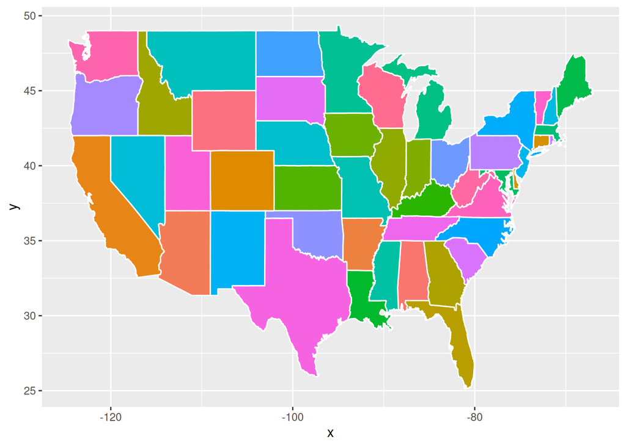

```r
# install.packages("ggplot2")
library(ggplot2)

# install.packages("maps")
library(maps)

df <- data.frame(x = state.center$x, y = state.center$y,
                 state = state.name)

p <- ggplot(df, aes(x = x, y = y)) +
       geom_polygon(data = map_data("state"),
                    color = "white",
                    aes(x = long, y = lat,
                        fill = map_data("state")$region,
                        group = group)) +
       guides(fill = FALSE)
p
```

In this guide we are going to use the following example plot.

ggplot2 map

Adding text with geom_text Use the geom_text function to add texts in ggplot2

Adding text annotations

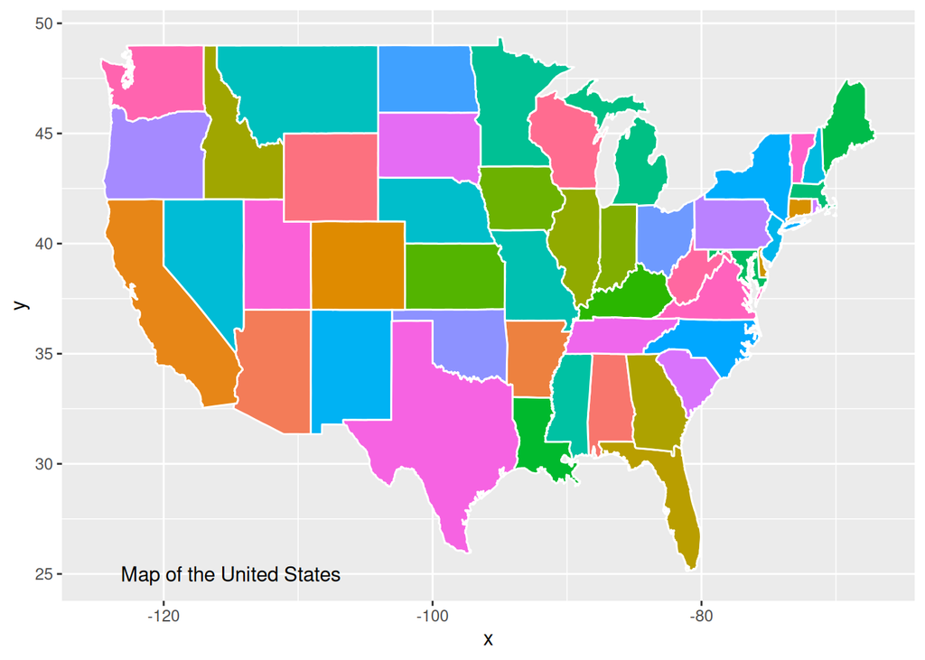

```r
p +
  geom_text(aes(x = -115, y = 25,
                label = "Map of the United States"),
            stat = "unique")
```

Set stat = “unique”, otherwise the label will be redrawn for each data point on your data frame.

Customize the size and the color of the text using geom_text

Customizing the annotations

There are several arguments that you can customize, such as the color or the size of the text.

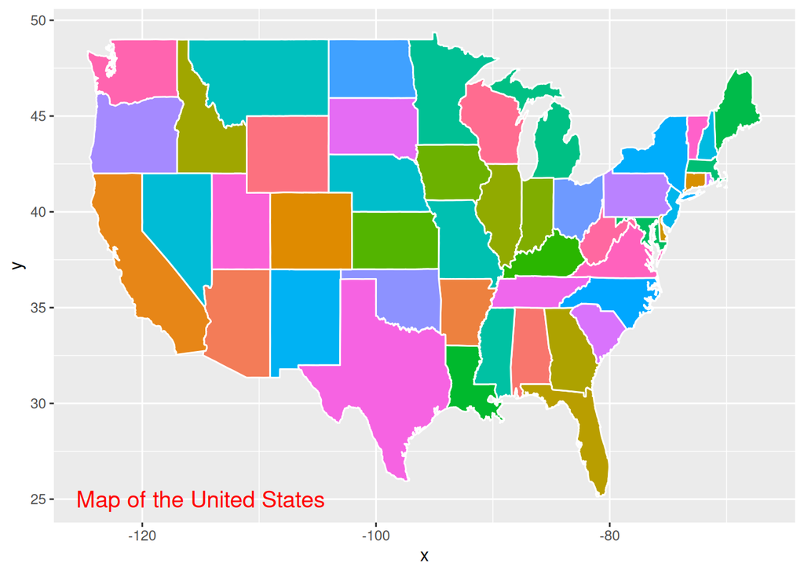

```r
p +
  geom_text(aes(x = -115, y = 25,
                label = "Map of the United States"),
            stat = "unique",
            size = 5, color = "red")
```

Label observations in ggplot2

If your data set contains a variable with groups or labels you can pass it to the label argument.

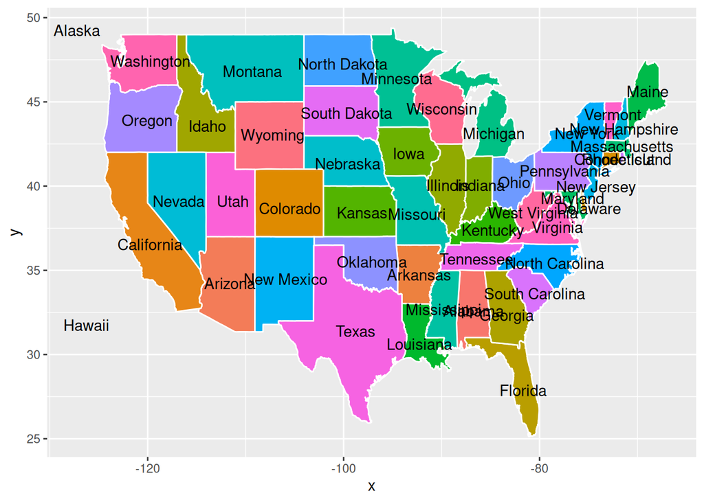

```r
p +
  geom_text(aes(label = state))
```

Adding labels with geom_label If you prefer adding labels instead of raw text use geom_label. The function behaves the same as the previous but with a background, making the text easier to read.

Label annotation

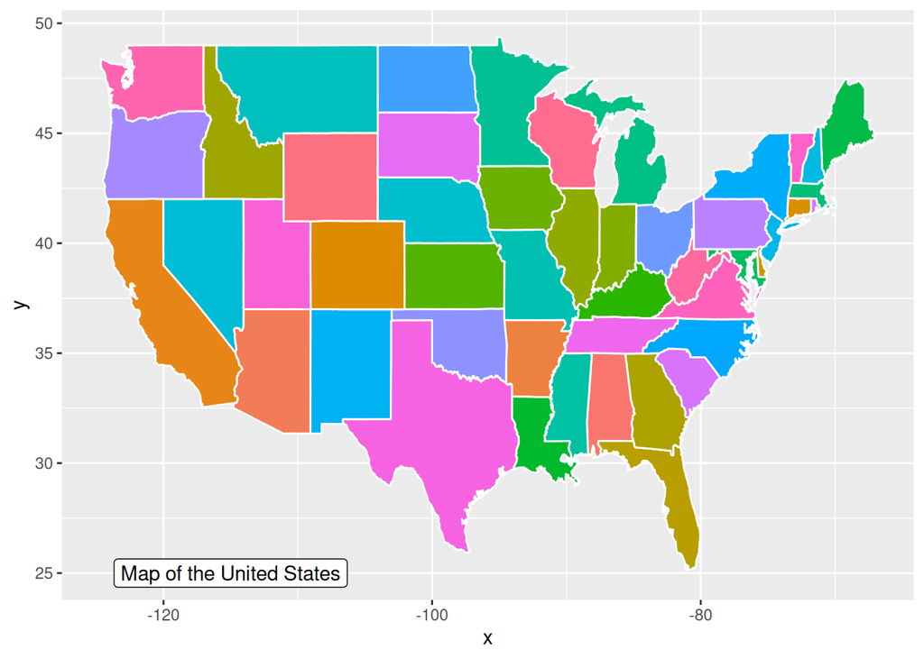

```r
p +
  geom_label(aes(x = -115, y = 25,
                label = "Map of the United States"),
            stat = "unique")
```

Use the geom_label function to add labels in ggplot2

Customizing the label

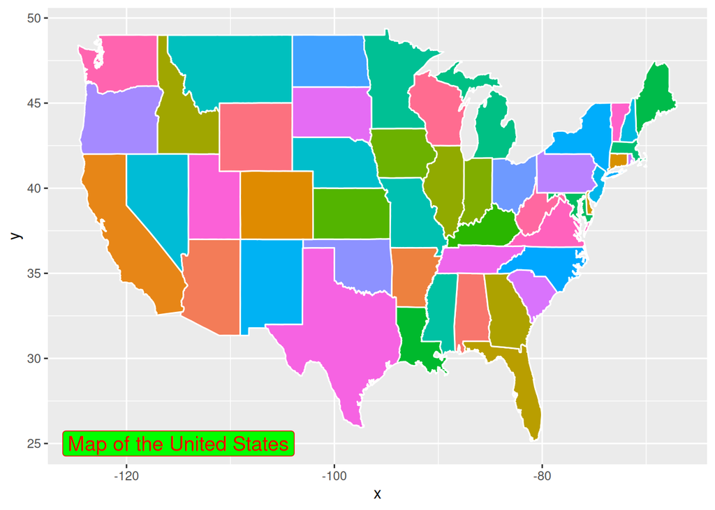

```r
p +
  geom_label(aes(x = -115, y = 25,
                label = "Map of the United States"),
            stat = "unique",
            size = 5, color = "red", fill = "green")
```

Customize the colors and size of geom_label

Labelling points

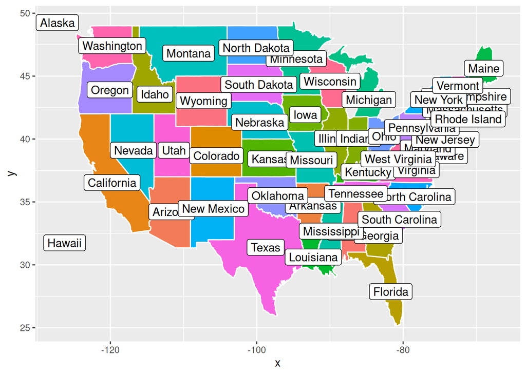

```r
p +
  geom_label(aes(label = state))
```

Labelling observations in ggplot2 with geom_label

Use ggrepel to avoid overlapping of the texts or labels.

Avoid overlapping with ggrepel The text and the labels are placed on the coordinates you set, but can overlap. The ggrepel package provides geom_text_repel and geom_label_repel functions, which make the labels repel away from each other as much as possible.

geom_text_repel function from ggrepel to avoid overlapping

geom_text_repel

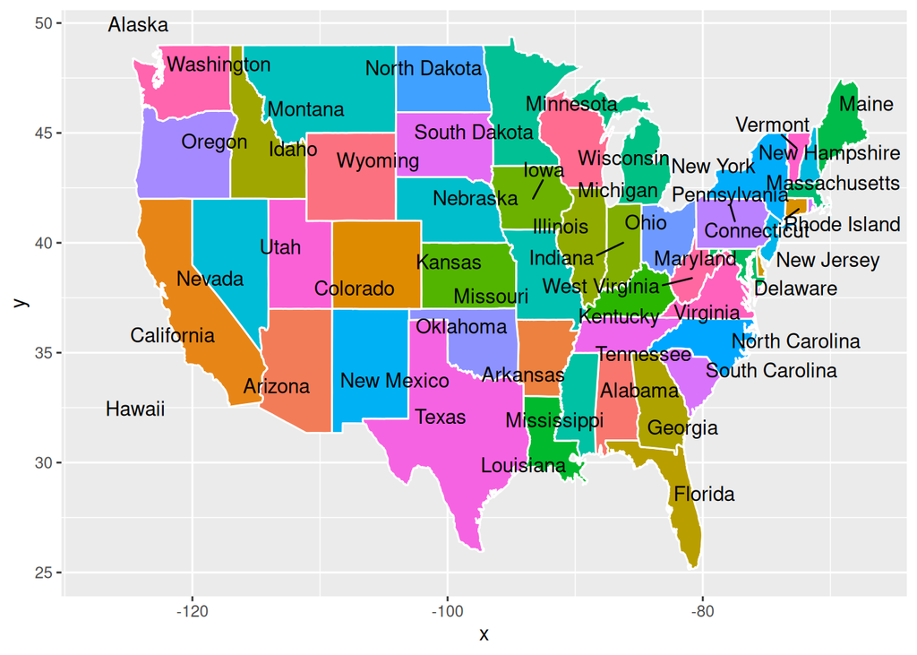

```r
# install.packages("ggrepel")
library(ggrepel)

p +
  geom_text_repel(aes(label = state))
```

Use the geom_label_repel function to add labels without overlapping in ggplot2

geom_label_repel

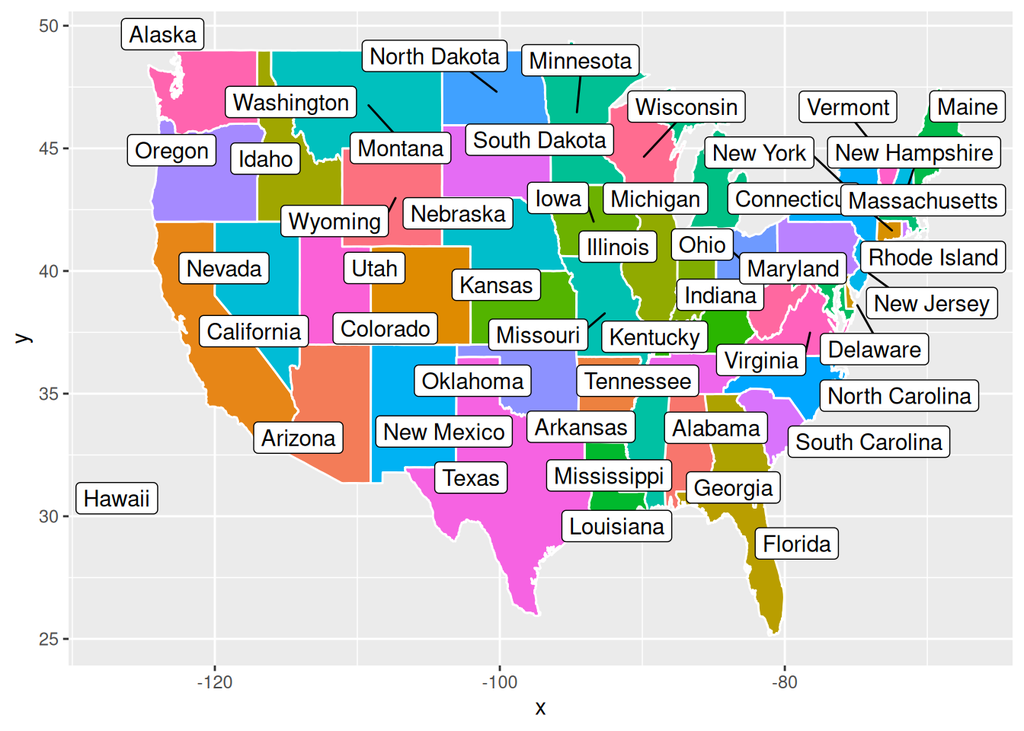

```r
# install.packages("ggrepel")
library(ggrepel)

p +
  geom_label_repel(aes(label = state))
```

You can customize the colors, fonts and other arguments the same way as with geom_text or geom_label. See the package examples for more use cases.

Use markdown and HTML with ggtext If you want to fully customize you annotations use the geom_richtext function from ggtext, which allows you to add markdown and HTML formatting to your text annotations.

Add rich text

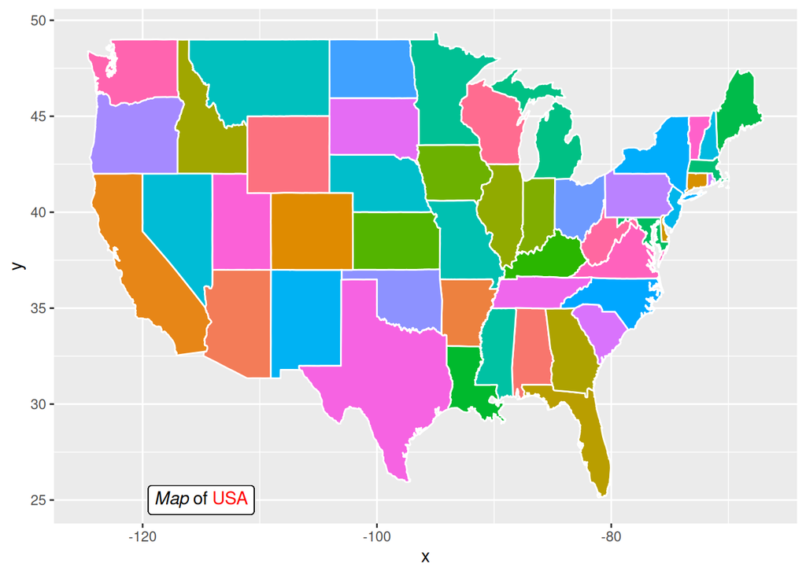

```r
# install.packages("ggtext")
library(ggtext)

lab <- "*Map* of <span style = 'color:red'>USA</span>"
p +
  geom_richtext(aes(x = -115, y = 25,
                    label = lab))
```

geom_richtext function to add rich text, HTML and markdown in ggplot2

Rotate the text

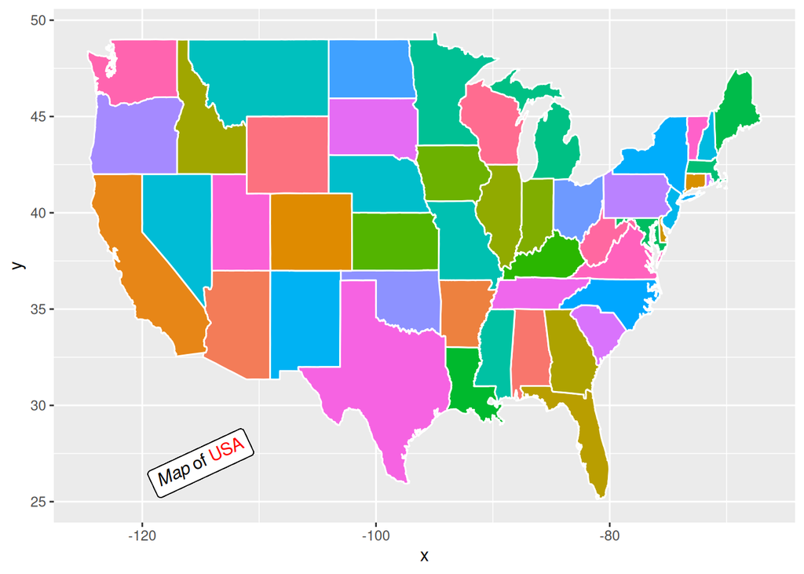

```r
# install.packages("ggtext")
library(ggtext)

lab <- "*Map* of <span style = 'color:red'>USA</span>"
p +
  geom_richtext(aes(x = -115, y = 27,
                    label = lab),
                angle = 25)
```

Rotate labels or texts in ggplot2

# Background color in ggplot2

## Plot border color

Changing the colors with themes Color picker Default plot

By default, ggplot2 plots have a gray panel and a white background.

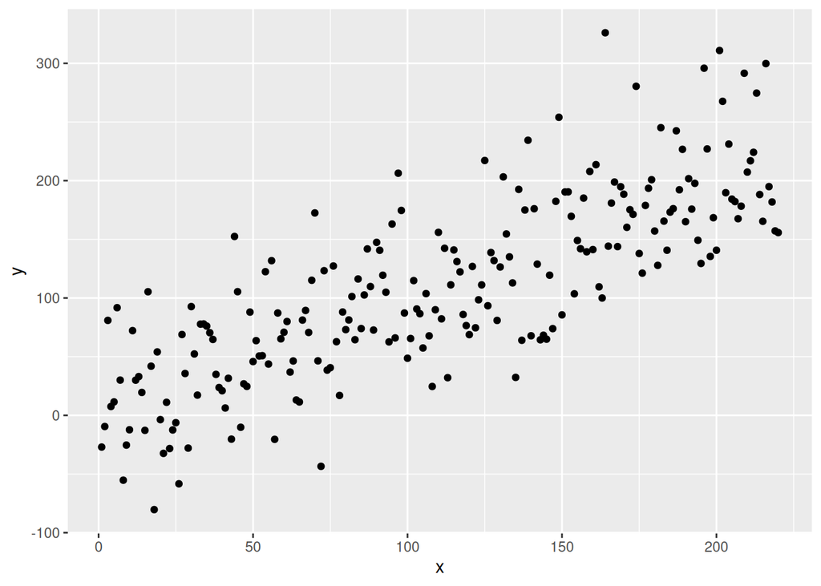

```r
library(ggplot2)

# Sample data
set.seed(123)
x <- 1:220
y <- x + rnorm(220, sd = 50)

df <- data.frame(x = x, y = y)

# Plot
ggplot(data = df, aes(x = x, y = y)) +
  geom_point()
```

Default background color in ggplot2

Panel background color You can change the panel background color setting an element_rect in the panel.background component of the theme function as follows.

Change the background panel color in ggplot2

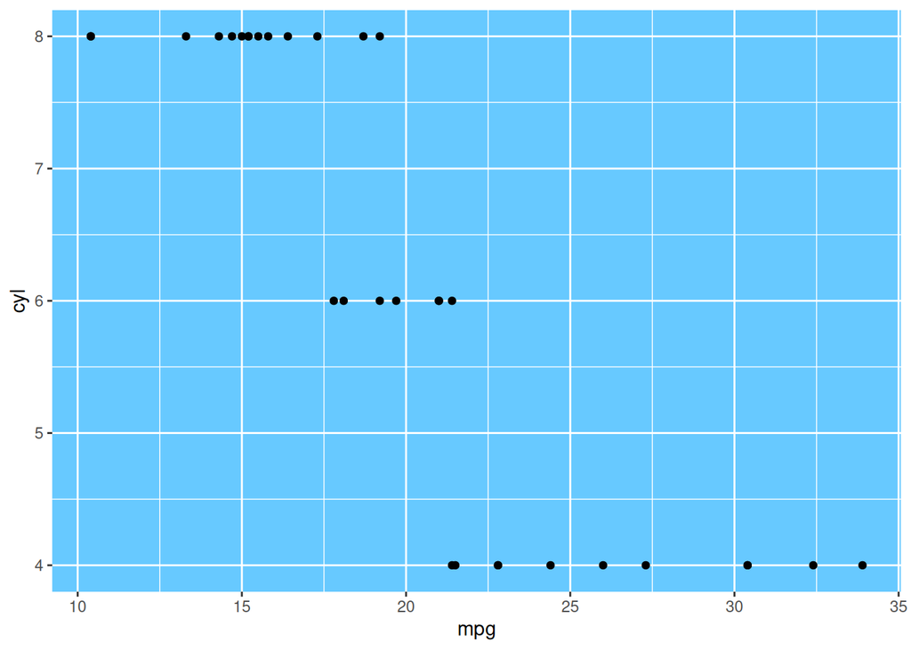

```r
library(ggplot2)

ggplot(data = mtcars, aes(x = mpg, y = cyl))+
  geom_point() +
  theme(panel.background = element_rect(fill = "#67c9ff"))
```

Panel border color Option 1

ggplot2 panel border color

The panel.border component of the theme function controls the color and width of the border of the panel with the color and size arguments. However, you will need to set fill = “transparent” to avoid hiding the data.

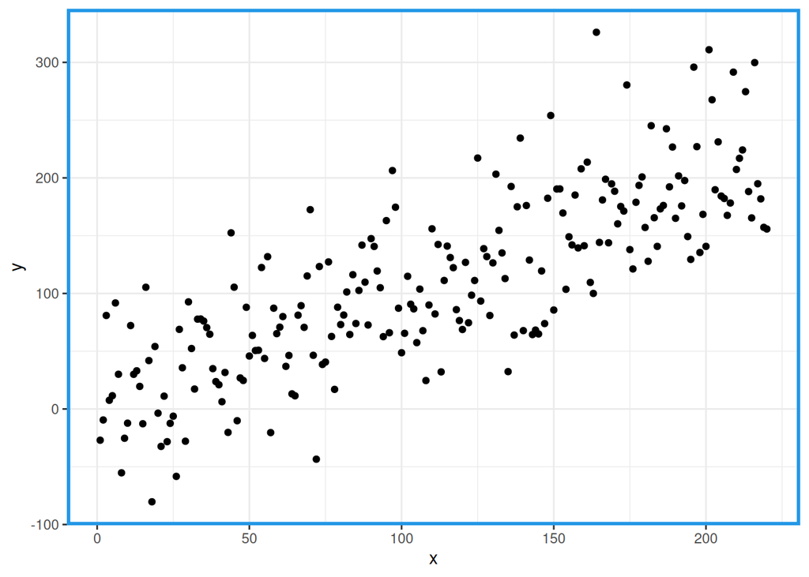

```r
library(ggplot2)

ggplot(data = df, aes(x = x, y = y)) +
  geom_point() +
  theme_bw() +
  theme(panel.border = element_rect(fill = "transparent", # Needed to add the border
                                    color = 4,            # Color of the border
                                    size = 2))            # Border width
```

Option 2

Border color of the plot in ggplot2

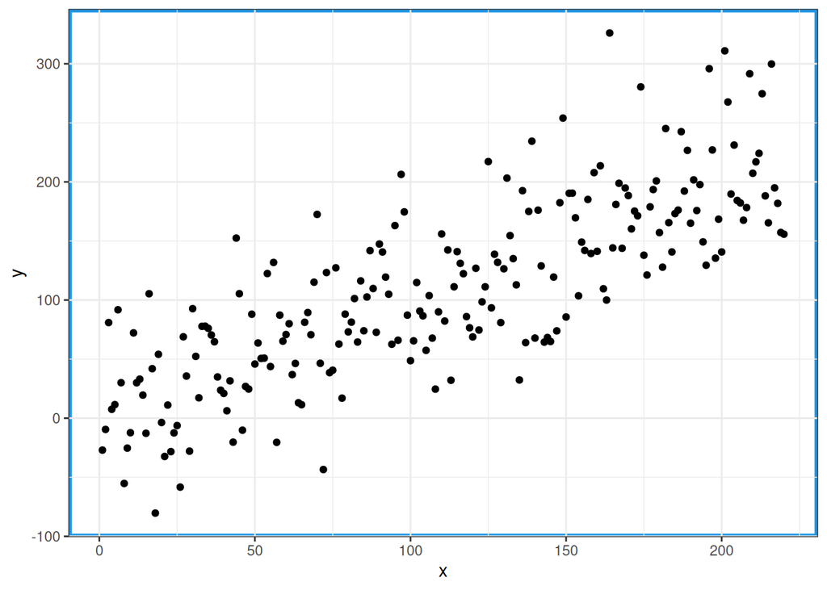

```r
library(ggplot2)

ggplot(data = df, aes(x = x, y = y)) +
  geom_point() +
  theme_bw() +
  theme(panel.background = element_rect(color = 4, # Color of the border
                                        size = 2)) # Border width
```

Plot background color The plot.background component of the theme function allows modifying the background color of the figure. Set the color inside the fill argument of an element_rect.

Plot background color in ggplot2

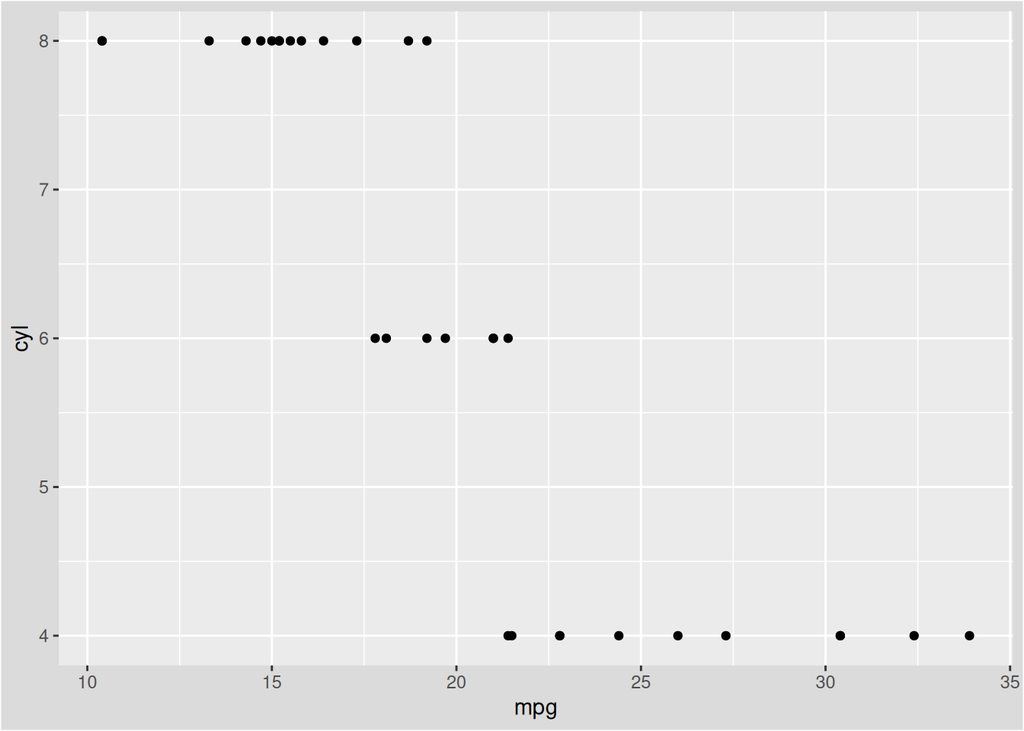

```r
library(ggplot2)

ggplot(data = mtcars, aes(x = mpg, y = cyl))+
  geom_point() +
  theme(plot.background = element_rect(fill = "gray86")) # Background color of the plot
```

Plot border color Plot border color in ggplot

You can also set a border color for the whole figure. Just pass an element_rect to the plot.background component of the theme function and modify the color and the width of the border with the arguments color and size, respectively.

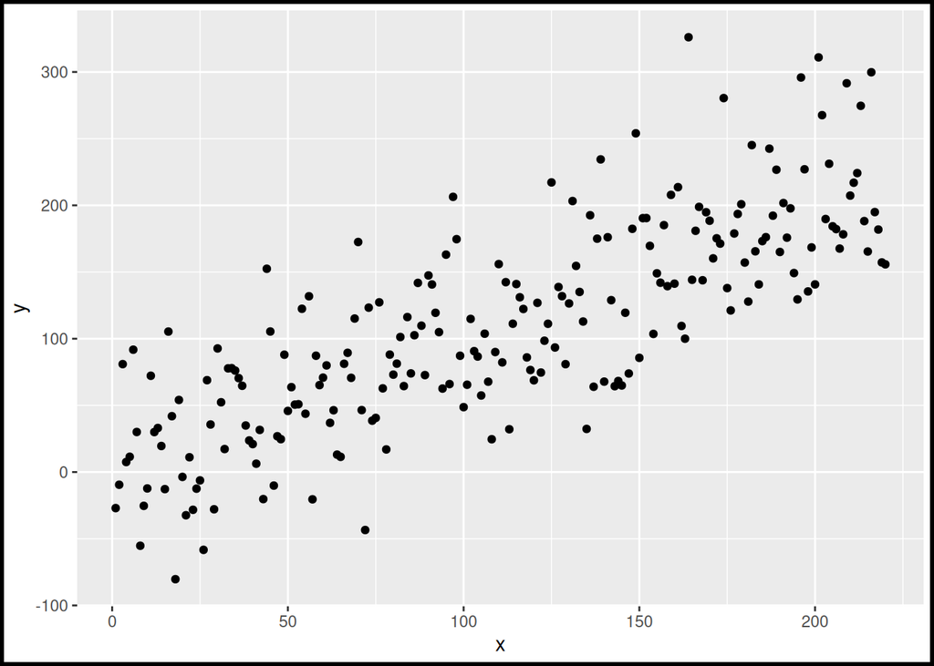

```r
library(ggplot2)

ggplot(data = df, aes(x = x, y = y)) +
  geom_point() +
  theme(plot.background = element_rect(color = "black", # Border color
                                       size = 2))       # Border width
```

Changing the colors with themes It is worth mentioning that there are lots of ggplot themes available that provide different background colors.

In this example we are setting the theme_dark, which is one of the in-built ggplot2 themes.

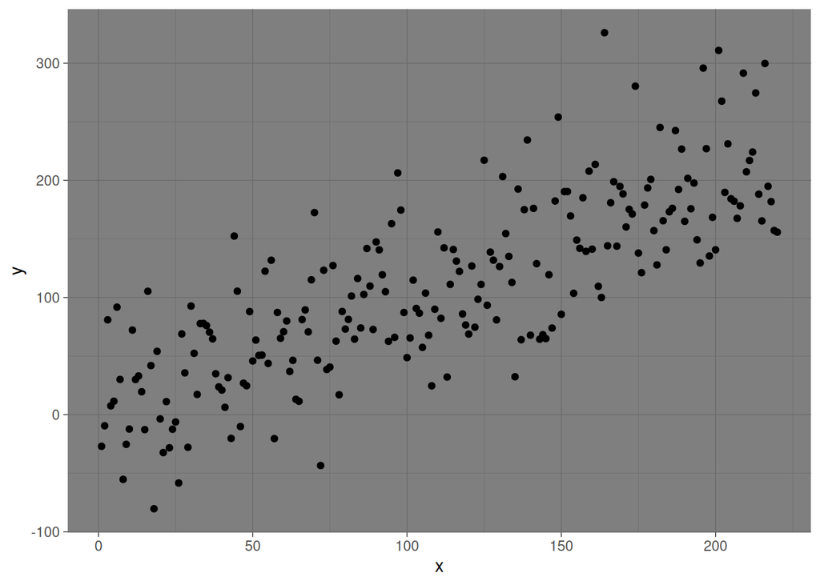

```r
library(ggplot2)

ggplot(data = df, aes(x = x, y = y)) +
  geom_point() +
  theme_dark()
```

Note that the default theme is theme_grey.

Change the color of a plot with a ggplot theme

# Grid customization in ggplot2

Grid customization Major grid Minor grid Custom grid breaks Remove grids By default, ggplot2 creates a major and a minor white grid as shown in the following figure.

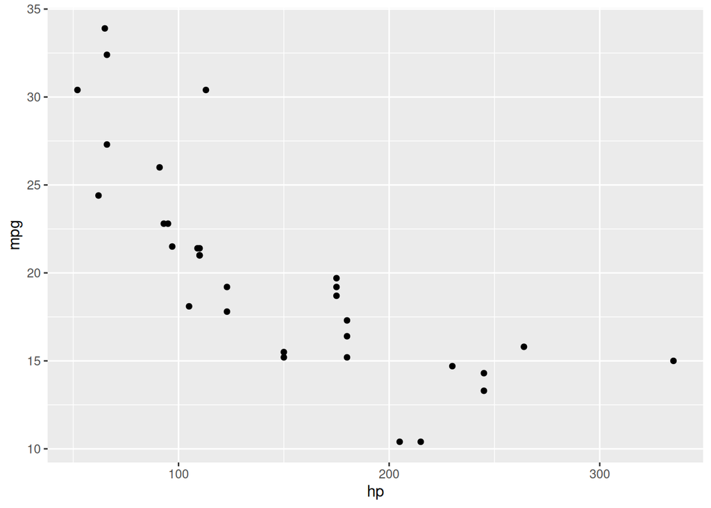

```r
library(ggplot2)
ggplot(data = mtcars, aes(x = hp, y = mpg))+
  geom_point()
```

Default ggplot2 grid

Grid customization Grid customization in ggplot2

The grid aesthetics can be set with the panel.grid component of the theme function. Customize the color, line width and line type with the arguments of the element_line function.

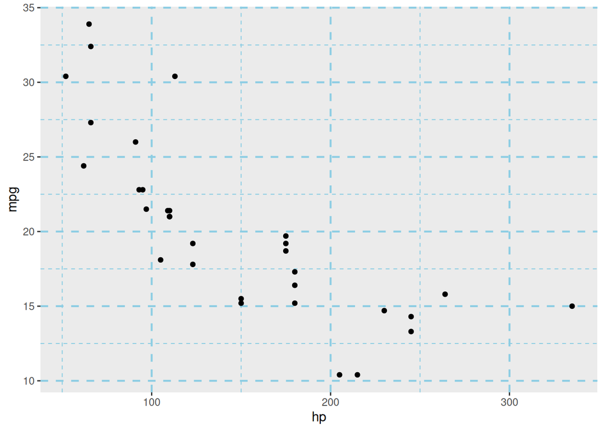

```r
library(ggplot2)

ggplot(data = mtcars, aes(x = hp, y = mpg)) +
  geom_point() +
  theme(panel.grid = element_line(color = "#8ccde3",
                                  size = 0.75,
                                  linetype = 2))
```

You can also customize the major grid and the minor grid individually, as shown in the following sections.

Major grid The panel.grid.major allows you to customize the major grid of the panel.

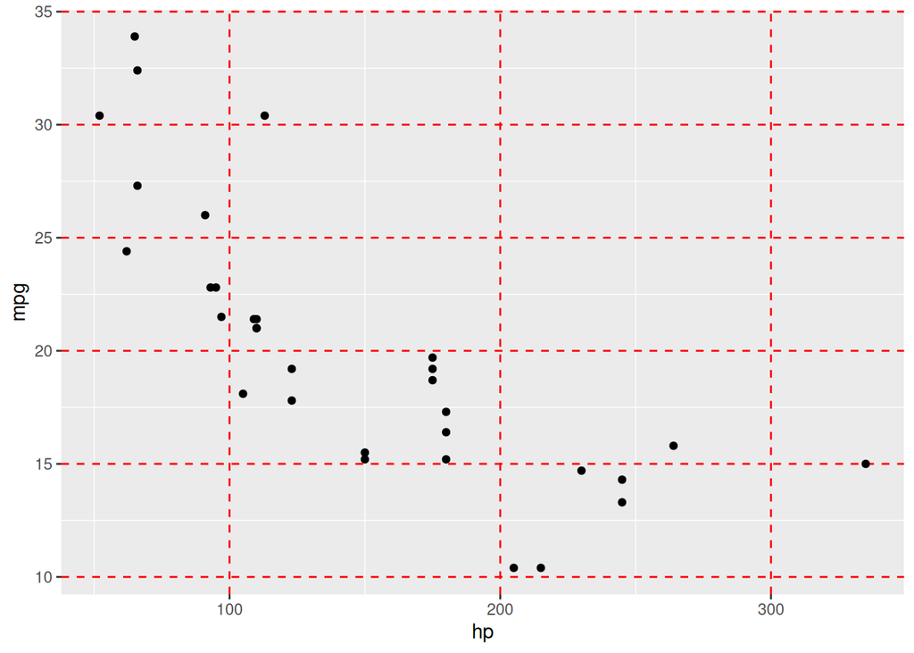

```r
library(ggplot2)

ggplot(data = mtcars, aes(x = hp, y = mpg)) +
  geom_point() +
  theme(panel.grid.major = element_line(color = "red",
                                        size = 0.5,
                                        linetype = 2))
```

Major grid in ggplot2